# COVID-19 Effects on the Real Estate Market

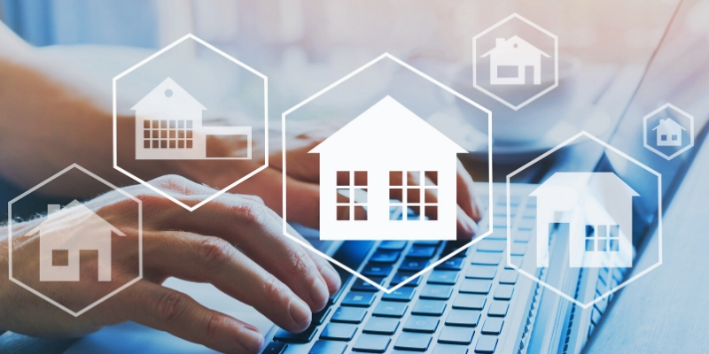

# Introduction

The median homeowner has 40 times the household wealth of a renter, according to the 2019 Survey of Consumer Finances, a triennial survey that collects detailed accounts of households’ finances (Kushi 2020). Other studies show that homeownership leads to greater wealth-building in comparison to renting. Thus, real estate and homeownership is still one of the best ways to build wealth, but is it really a good investment and does it perform well throughout economic downturns? Specifically how did it perform throughout the COVID-19 pandemic?

This Covid-19 related recession seems different in comparison to previous recessions as previous recessions saw a steep decline in price. Despite flashbacks of the 2008 financial crisis and recessionary concerns due to the pandemic, the real estate frenzy has reignited after a short downturn. Many houses are selling well over asking price due to heavy competition and single family home inventory is at ⅔ of last year’s based on Aug 2019 and 2020. Demand is growing while supply is decreasing, snowballing the real estate market into a hot, competitive market. This is increasing the barrier to entry as the amount of capital needed to purchase real estate is also growing.

In order to examine such phenomena mid-pandemic, we seek to answer, *‘How did the COVID-19 pandemic impact the real estate industry?’ ‘How well has the real estate market performed compared to other markets?’* and *‘What explains this real estate market behavior?’*

# Overview of Analysis

We look to explore the single family real estate market and the impact of COVID-19 on the market. We specifically are looking at single family homes (SFH) because of the higher liquidity within the market, lowest barrier to entry, and because commercial data is not publicly available.

In order to analyze the impact of Covid on the real estate market, we first turn to the impact on national sales volume regarding SFH. Then we seek any differences between average home prices of the US and certain states. Then we seek to understand the real estate on a more granular level by analyzing how prices were impacted by state. This will help us understand how overall the supply and demand of the market affected the prices and quantities that homes are selling for.

Once we realize the overall market effects, we examine how the real estate market has performed vs other markets. We do this by comparing the Home Price Index with the Consumer Price Index and the S&P 500. This will allow us to understand how the real estate market performed in comparison with the average cost of living and compared to the top 500 stocks in the US.

Then we try to understand what developments caused the market to react in the way that it did. Two common allegations are that it is because interest rates are low and because construction costs are high. Thus we plotted the interest rate and home price to understand the relationship between interest rates and home prices. Then, we compared the percentage change between construction material costs and building permits approved to examine the relationship between construction costs and newly built homes.

# Data

Our data was extracted from a variety of sources such as the Federal Reserve Bank of St. Louis, US Census, and Zillow.

The data for national home sales count and median home sale price came from Zillow.

[Zillow](https://www.zillow.com/research/data/)

The data for CPI, HPI, and S&P 500 came from the Federal Reserve Bank of St. Louis, also known as the FRED.

[HPI](https://fred.stlouisfed.org/series/CSUSHPINSA)

[CPI](https://fred.stlouisfed.org/series/USACPIALLMINMEI)

[S&P 500](https://fred.stlouisfed.org/series/SP500)

We found our data for the building permits came from the Building Permits Survey from the US Census data. This dataset provides data on the number of new housing units authorized by building permits. Finally, the construction material index was sourced from the Federal Reserve Bank of St. Louis the FRED.

[BPS](https://www.census.gov/construction/bps/)

[Construction Materials Index](https://fred.stlouisfed.org/series/WPUSI012011)

# US National Sale Volume Changes

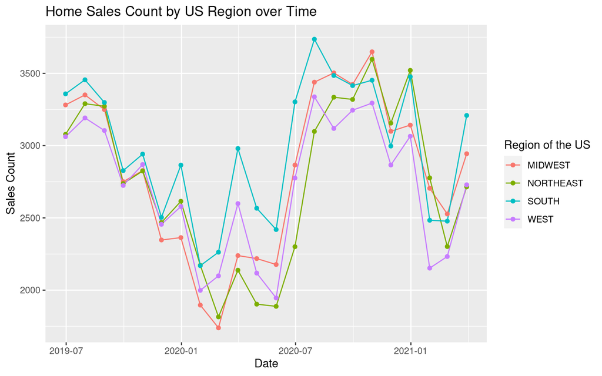

We tracked the patterns in national sale volume over time, from July 2019 to March 2021. From this visualization, we can see that national sales hit a sharp downturn and reached its lowest point in Feb-March 2020, then began to spike back up in April and into the summer. The first trend can be explained by the nationwide lockdown, as all businesses (e.g. real estate agencies) were forced to shut down or operate remotely, and fear about the pandemic and its transmission were at an all-time high. The second trend can be explained by the “suburban shift” and exodus to low-tax states, as the remote economy no longer required proximity to urban centers and encouraged workers to move to larger homes. These trends can be seen across different regions of the US - each of the four lines follow a similar pattern. Such similarity indicates that these trends are nationwide, and thus likely caused by nationwide occurrences (like a global pandemic). However, we see another downturn in Jan 2021, as surging home prices (due to low supply and high demand) made home purchases less affordable for the average consumer.

# US Average Home Price Changes

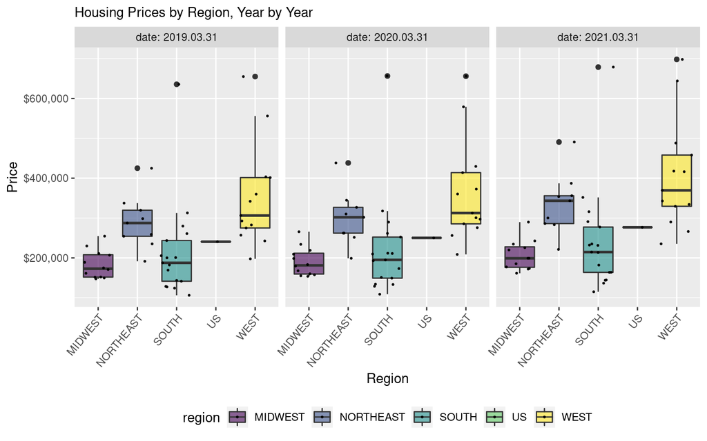

We created a box plot to track the average housing prices over the past three years by region using data from Zillow’s research database. This visualization provides us with some compelling information about the affect of the pandemic on the housing market. The first thing we noticed is that the pandemic turned real estate into a seller’s market. Not only did housing prices in each region increase during the pandemic, but also each region grew at a faster rate during the pandemic, from 2020 to 2021, than in the year leading up to pandemic. That means the pandemic actually is correlated with the speeding up of the increase in real estate prices. This effect happened nationwide, as prices did not decrease in any region. Moreover, we see that the most growth came from the west region.

# Home Price by State, Interactive Spatial Map

[interactive chart not shown]

This map makes one thing clear: location is everything. Average house prices range by a shocking amount. The average price of a home in California is $644,000 compared to $115,000 in West Virginia (California is over 4 times more expensive). The expensive housing in California can be explained both by the lack of supply that cannot keep up with the demand for homes and the heavier regulation of land which bumps up prices. In addition, this map corroborate with the box plot that the West is the most expensive region in America, and that both coasts are significantly more expensive that the middle of the country. By clicking on each state, you can see how much the prices have increased since last year. North Dakota had the least year over year growth at a rate of 3.7% and Idaho had the most growth since last year at a rate of 22.9%. This is due to the increasing cost of building materials and swelling demand in Idaho. In every state, the pandemic year provided housing prices with growth with no states deviating from this trend.

# Comparison of Housing Price Index, Consumer Price Index, and S&P 500

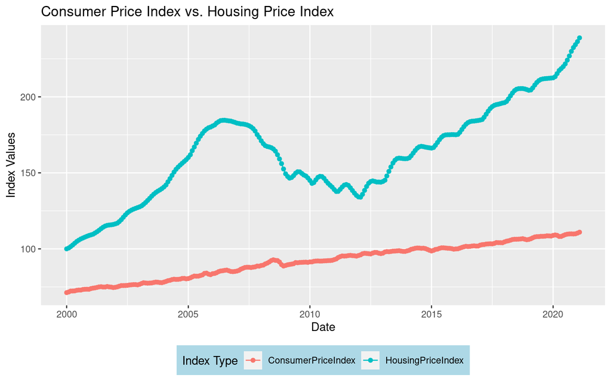

The HPI has outperformed the CPI over the course of 20 years and certainly stands as an asset class that appreciates faster than the cost of living. Although we do see a large crash between 2008-2012, we can see that the HPI has recovered even higher than the past peak. We also see that the CPI has increased in a stable fashion. The housing market thus seems like a more volatile compared to the living expenses of the average US citizen, but better returns. This indeed allows us to realize that investing in real estate is more likely than not to grow and is a better alternative to holding cash. However, we also look to see how real estate has performed compared to the stock market in the form of the S&P 500 index. Specifically during the pandemic, we also see that the HPI increased at record rates.

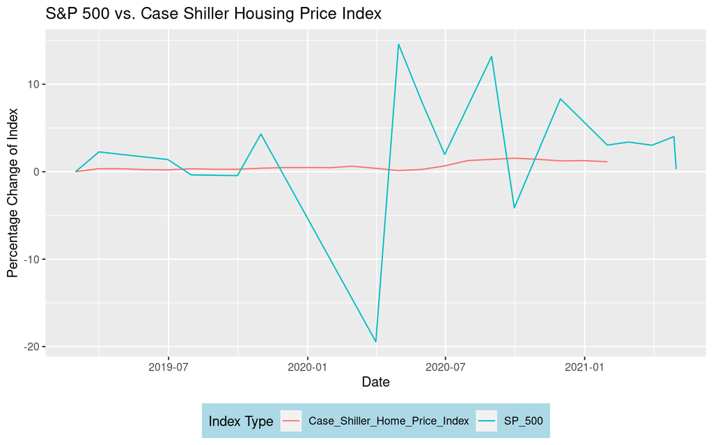

In comparison with the S&P 500, we can see that the HPI is much more stable compared to the volatility of the stock market. While the HPI averages around 2-3%, we can see that the S&P 500 grows at a 7% average. In this case, we can see that the top 500 stocks will perform better than the average house in the US. However, there are some caveats that need attention. First is that the S&P 500 tracks the top 500 stocks while the HPI tracks all home values. Thus, it is not the best comparison when comparing returns due to the fact the HPI considers personal residencies that do not try to achieve the returns of investment properties, while all S&P 500 companies are trying to achieve a high return. In addition, the HPI only tracks appreciation and does not reflect the true returns of real estate. This is because tax benefits from depreciation and 1031 exchanges, principal and interest pay down, leverage, and cash flow are largely ignored in the HPI.

The difference in volatility may be explained in the liquidity and efficiency of the market. Stocks are able to be bought and sold in a relatively quick manner while real estate may take weeks, months, or even years to buy or sell properties. Thus, market changes are much more pronounced in the stock market while changes may be slow to show in the real estate market. In addition, real estate is generally a more stable asset in comparison to stocks, so the volatility also reflects the risk profile of each asset.

# Interest and Home Price Relationship

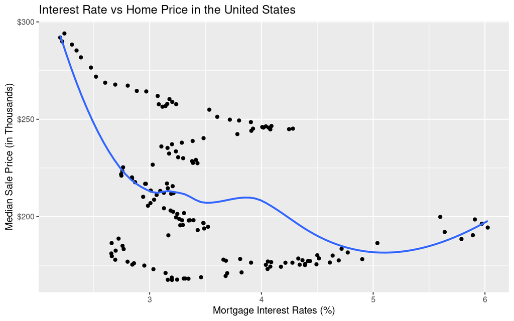

The downward-sloping line of best fit demonstrates the negative correlation between interest rates and home price. Looking at monthly data since 2008, as interest rates rose, median home price generally fell. We can infer that this is due to the attractiveness of spending and investing during periods of low interest rates - loans for large investments like real estate will accrue less interest and therefore prove less costly over time during periods of low interest rates. Thus, demand for real estate increases, pushing up prices. This relationship can help explain the surge in the real estate market during the pandemic - as interest rates fell, investments in real estate became more attractive, especially during a time when remote work and stay-at-home orders encouraged moving to larger spaces with lower taxes.

# Construction Material Costs and Building Permits Changes

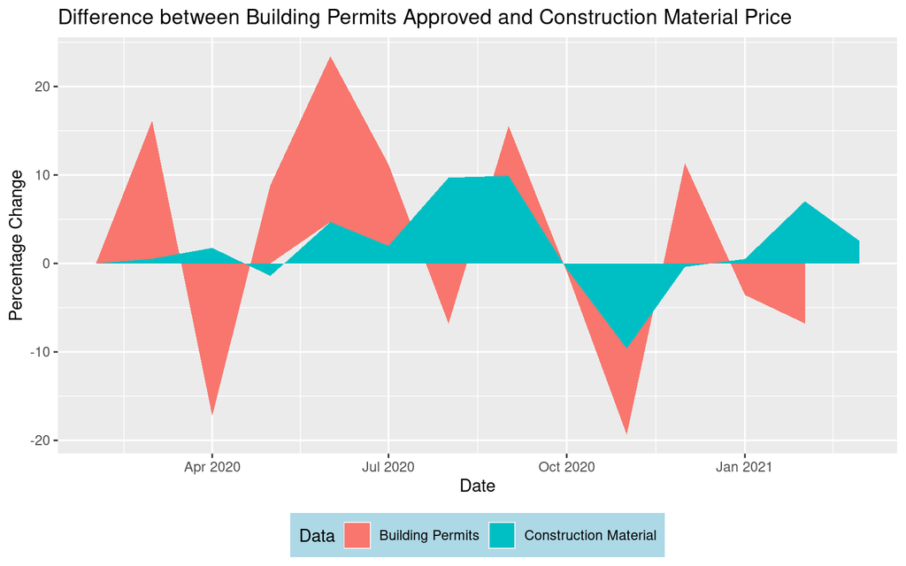

# Conclusion and Limitations

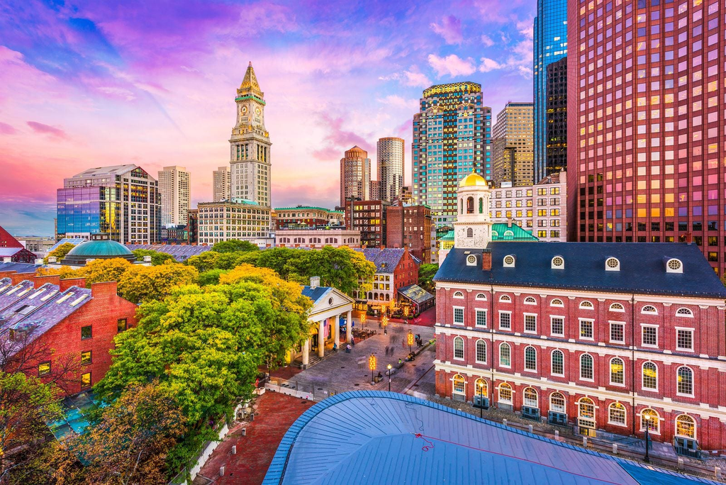

## Answering Questions of Interest

**1. How did the COVID-19 pandemic impact the real estate industry?**

**2. How well has the real estate market performed compared to other markets?**

We found that, despite the pandemic, real estate has performed well in comparison to other assets. In comparison to the CPI, we were able to observe that real estate historically beat out inflation. However, in comparison to the S&P 500, it lacked the returns. However, it was much less volatile than stocks during distressed times as a stable investment. However, this may be due to the forbearance and foreclosure protection, so it will be interesting to see how the market develops once these protections have dissolved.

Yet this comparison does not factor in the benefits of owning real estate and the adjusted returns incorporating such benefits. The HPI shows the average appreciation of homes, but does not include the depreciation, tax benefits, cash flow, loan pay down, leverage, and forced appreciation that homeowners enjoy.

This also does not include the 1031 exchange, which allows homeowners defer their taxes to later years and sell their property to buy a greater or equal value home. This in turn allows the investor to invest pre-tax cash to achieve higher returns with a bigger bankroll. Thus, while some investors may consider real estate an inferior investment to stocks based on these indexes, they fail to realize the unrecorded benefits of real estate.

**3. What explains this real estate market behavior?**

Our findings on the negative correlation between interest rate and sale price indicate that lower interest rates lead to higher demand for real estate and therefore higher sale prices. Thus, the Fed’s response in early 2020 to support the US economy during the lockdown by slashing down to near-zero interest rates could explain the surge in sales count and sales price (Cheng et al. 2021).

## Limitations

One limitation to our study is that the real estate market does not have perfect information and includes a large off-market section. We are unable to track these transactions and thus does not provide the full picture of all real estate transactions. However, we are able to track those listed on MLS and sites such as Zillow and Redfin, which allow us to graspe a general sense of the real estate market.

Our construction data and findings could also be limited by government bureaucracy. Government and market move at different paces, the government might approve permits at different dates than the application. Thus, building permits approved may not yet accurately reflect the larger claims we believe to be true for supply of homes.

Finally, the HPI does not accurately reflect the return on investment because it only factors in home price appreciation. As mentioned before, the HPI does not include the tax benefits, loan pay down, leverage, forced equity, and cash flow. Although appreciation is a significant amount, these factors can vary wildly and will influence the return immensely. Thus the HPI and S&P 500 comparison has some limitations as the HPI doesnt provide the full picture, but the conclusions of volatility still stand.

## Possible Next Steps

Possible next steps would to understand the debt markets of real estate and see the impact of Covid on mortgages. For instance, we can track missed and late payment percentages and see how Covid impacted those numbers. In addition, we could see how the total mortgage debt of the US was impacted by Covid and if the mortgage growth rate was irregular during this period. This will also help us to understand the impact of forebearance and foreclosure protection, alongside eviction protection.

Another angle that would be interesting to look at are different asset classes. We focused on the SFH market, but there are various other asset classes such as multifamily, industrial, retail, hotels, land, and office. However, publicly available data is limited so a subscription to Loopnet or a commercial Multiple Listing Service (MLS) would be extremely helpful in this instance.

Although this was an overall analysis of the US real estate market, geography plays a massive part. Thus, it may be more interesting to look into specific states, counties, and neighborhoods to understand how the pandemic has affected local markets.

# Citations

Odeta Kushi. “Homeownership Remains Strongly Linked to Wealth-Building.” Nov 5, 2020. https://blog.firstam.com/economics/homeownership-remains-strongly-linked-to-wealth-building/

Cheng et al. “What’s the Fed doing in response to the COVID-19 crisis? What more could it do?” March 30, 2021 https://www.brookings.edu/research/fed-response-to-covid19/